# publicSchoolsGLPCCR Project - Facts and Figures

D. Hopp

October 2017

## Handy Facts and Figures for 2016-17 Grades 3, 4, and 5 for Public and Charter Schools

In 2016-17 there were `1369` public (non-charter) schools and `142` charter schools that had students in grades 3, 4, and 5.

| charter | group | total | pct |
| --- | --- | --- | --- |
| No | ALL | 337891 | 100 |
| No | BLCK | 81004 | 24 |
| No | HISP | 55717 | 16 |
| No | WHTE | 156065 | 46 |

| charter | group | total | pct |
| --- | --- | --- | --- |
| Yes | ALL | 23810 | 100 |
| Yes | BLCK | 5976 | 25 |
| Yes | HISP | 1310 | 6 |
| Yes | WHTE | 12502 | 53 |

There was a pronounced difference between the proportion of economically disadvantaged students (EDS) in the public and the charter schools.

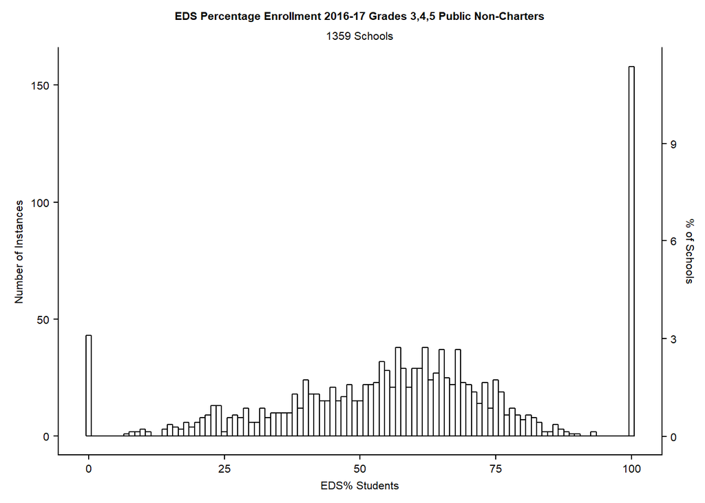

**Figure 1. Public Non-Charter Schools**

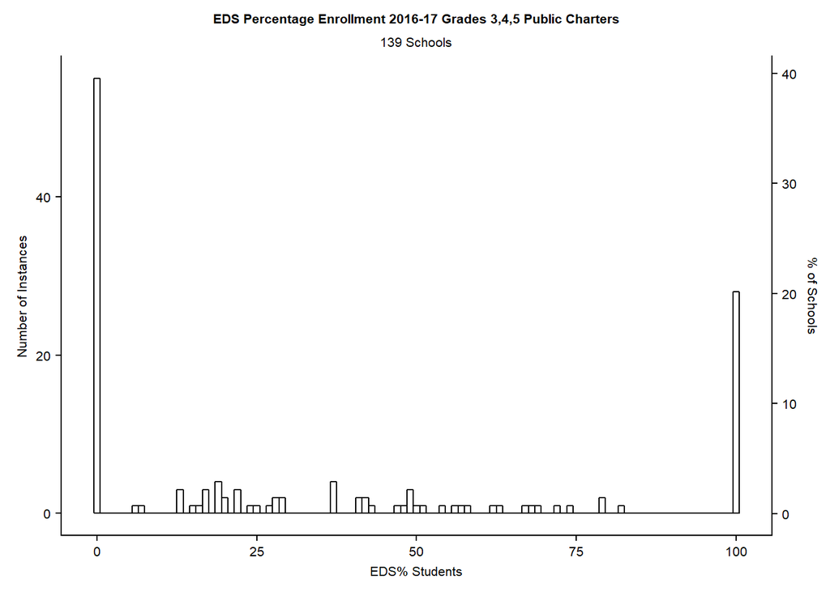

**Figure 2. Public Charter Schools**

### Performance 2016-17 GLP%

Report_A shows several plots of performance (GLP%) looking at all grade 3, 4, and 5 schools. Here I will compare public non-charter to charter schools. Figure 3 shows 2016-17 Grade 5 Mathematics, and Figure 4 shows Reading.

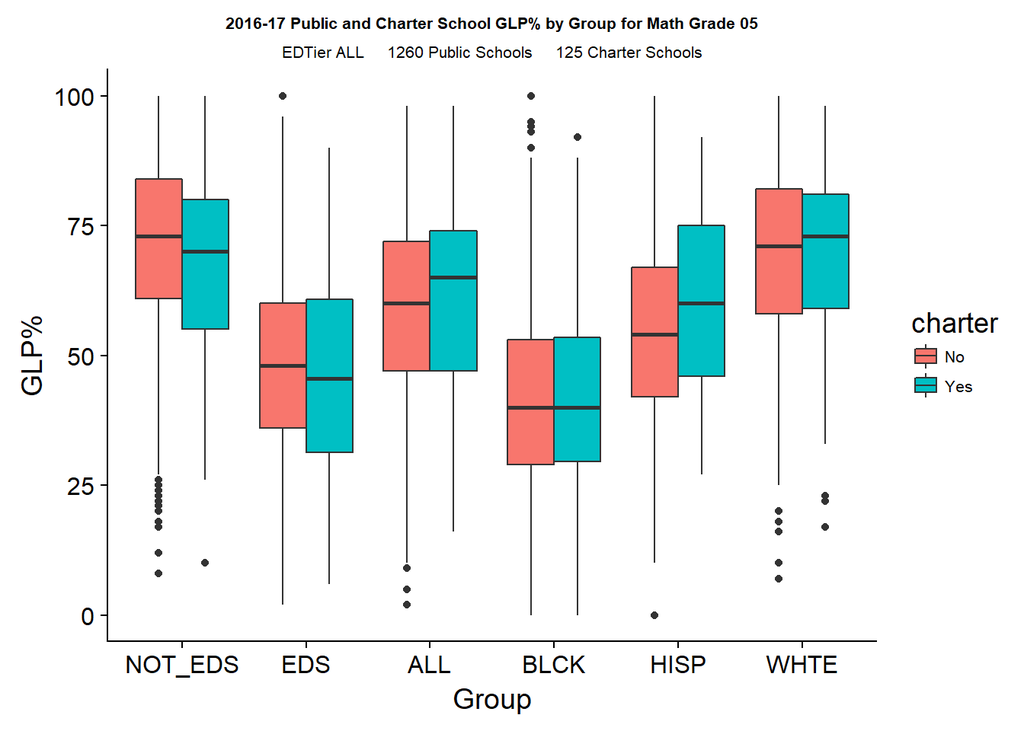

**Figure 3.**

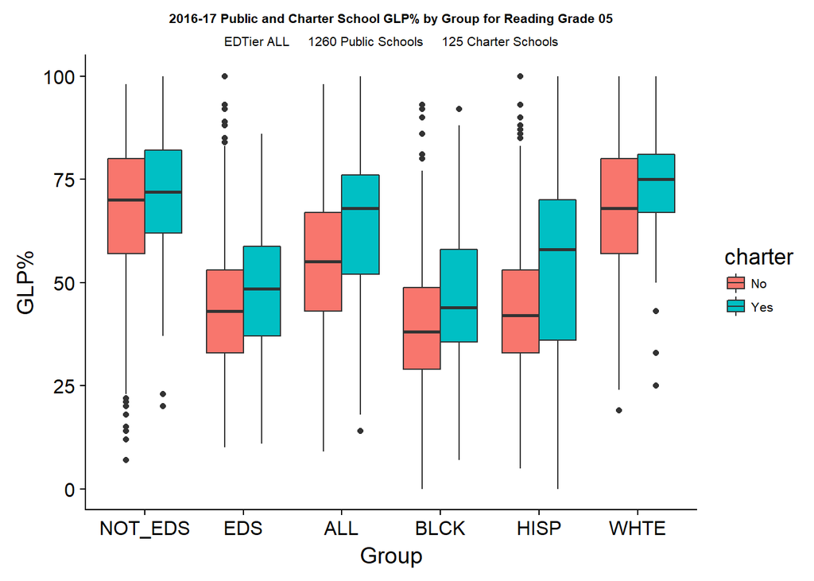

**Figure 4.**

The immediate impression is that, broadly speaking, charter schools demonstrate better performance (GLP%) that the non-charters. However, I have already shown in Figure 2 that the charters tend to have proportionately fewer EDS students than do the non-charters, and from Report A, that EDS students perform notably less well than do the non-EDS students. If follows that, at least to some extent, the charters would do better than the non-charters.

I have used a simple weighted means t-test to compare the EDS GLP% for charter and non-charter schools, for each of the four years, by grade and subject (math and reading). The differences in means that have statistical significance are those with p.value less than 0.025 (this is the 95% confidence level with a Bonferroni correction of 2 applied).

| acYear | subject | grade | mean.P | mean.C | p.value |
| --- | --- | --- | --- | --- | --- |
| 2013-14 | MA | 03 | 47.81733 | 47.36209 | 0.8731250 |
| 2013-14 | MA | 04 | 39.66801 | 37.60428 | 0.4349103 |
| 2013-14 | MA | 05 | 42.36605 | 43.65385 | 0.6622707 |
| 2013-14 | RD | 03 | 45.94372 | 49.30640 | 0.2262604 |
| 2013-14 | RD | 04 | 40.38487 | 42.37814 | 0.3796479 |
| 2013-14 | RD | 05 | 38.26686 | 42.02759 | 0.1663235 |

| acYear | subject | grade | mean.P | mean.C | p.value |
| --- | --- | --- | --- | --- | --- |
| 2014-15 | MA | 03 | 48.85378 | 50.39281 | 0.5752322 |
| 2014-15 | MA | 04 | 41.73200 | 41.95860 | 0.9287606 |
| 2014-15 | MA | 05 | 42.90272 | 45.70639 | 0.3338215 |
| 2014-15 | RD | 03 | 44.68836 | 49.81623 | 0.0341301 |
| 2014-15 | RD | 04 | 44.25947 | 52.54693 | 0.0003038 |
| 2014-15 | RD | 05 | 36.64205 | 43.70217 | 0.0025364 |

| acYear | subject | grade | mean.P | mean.C | p.value |
| --- | --- | --- | --- | --- | --- |
| 2015-16 | MA | 03 | 52.73371 | 50.96269 | 0.4576305 |
| 2015-16 | MA | 04 | 43.48944 | 42.54331 | 0.7082681 |
| 2015-16 | MA | 05 | 46.71811 | 45.40418 | 0.6215506 |
| 2015-16 | RD | 03 | 43.93575 | 47.12991 | 0.1280378 |
| 2015-16 | RD | 04 | 43.72896 | 49.54882 | 0.0054743 |
| 2015-16 | RD | 05 | 39.99050 | 46.71148 | 0.0031316 |

| acYear | subject | grade | mean.P | mean.C | p.value |
| --- | --- | --- | --- | --- | --- |
| 2016-17 | MA | 03 | 51.32363 | 52.09493 | 0.7179737 |
| 2016-17 | MA | 04 | 44.51036 | 42.47650 | 0.3601199 |
| 2016-17 | MA | 05 | 46.68768 | 45.58248 | 0.6183013 |
| 2016-17 | RD | 03 | 43.31519 | 46.80204 | 0.0591284 |
| 2016-17 | RD | 04 | 42.91232 | 48.24040 | 0.0016642 |
| 2016-17 | RD | 05 | 41.33066 | 47.01967 | 0.0032332 |

It can be seen that there are `6` instances of the `24` total where there is a significant difference in the means, all appearing in grade 4 and 5 Reading. This should be considered within the context that I established in Report A, namely, that aggregate measures are to be considered more reliable than the “fine details.” In this EDS GLP% comparison, I suggest that these significant differences in means are suggestive of actual positive consequences, but are not definitive. They serve to direct attention to high scoring charters and to see if there are consistent behaviors.

FINIS